# Risk Factor Analysis

## Outcome Variable

**Outcome Variable:** dead0plus

## Predictor Variables

**Intervention Variable:** ever_underweight024

**Adjustment Set:**

- sex
- arm
- brthmon
- vagbrth
- hhwealth_quart
- W_mage
- W_mhtcm
- W_mwtkg
- W_mbmi
- W_meducyrs
- W_feducyrs
- W_nrooms
- W_parity
- impsan
- safeh20
- delta_vagbrth
- delta_hhwealth_quart
- delta_W_mage
- delta_W_mhtcm
- delta_W_mwtkg
- delta_W_mbmi
- delta_W_meducyrs
- delta_W_feducyrs
- delta_W_nrooms
- delta_W_parity
- delta_impsan
- delta_safeh20

## Stratifying Variables

The analysis was stratified on these variable(s):

- studyid
- country

## Data Summary

| studyid | country | ever_underweight024 | dead0plus | n_cell | n | outcome_variable |
| --- | --- | --- | --- | --- | --- | --- |
| Burkina Faso Zn | BURKINA FASO | 0 | 0 | 4725 | 7165 | dead0plus |
| Burkina Faso Zn | BURKINA FASO | 0 | 1 | 22 | 7165 | dead0plus |
| Burkina Faso Zn | BURKINA FASO | 1 | 0 | 2392 | 7165 | dead0plus |
| Burkina Faso Zn | BURKINA FASO | 1 | 1 | 26 | 7165 | dead0plus |
| EE | PAKISTAN | 0 | 0 | 53 | 380 | dead0plus |
| EE | PAKISTAN | 0 | 1 | 0 | 380 | dead0plus |
| EE | PAKISTAN | 1 | 0 | 323 | 380 | dead0plus |
| EE | PAKISTAN | 1 | 1 | 4 | 380 | dead0plus |
| GMS-Nepal | NEPAL | 0 | 0 | 220 | 697 | dead0plus |
| GMS-Nepal | NEPAL | 0 | 1 | 2 | 697 | dead0plus |
| GMS-Nepal | NEPAL | 1 | 0 | 470 | 697 | dead0plus |
| GMS-Nepal | NEPAL | 1 | 1 | 5 | 697 | dead0plus |
| iLiNS-DOSE | MALAWI | 0 | 0 | 1164 | 1931 | dead0plus |
| iLiNS-DOSE | MALAWI | 0 | 1 | 63 | 1931 | dead0plus |
| iLiNS-DOSE | MALAWI | 1 | 0 | 639 | 1931 | dead0plus |
| iLiNS-DOSE | MALAWI | 1 | 1 | 65 | 1931 | dead0plus |
| iLiNS-DYAD-M | MALAWI | 0 | 0 | 775 | 1205 | dead0plus |
| iLiNS-DYAD-M | MALAWI | 0 | 1 | 18 | 1205 | dead0plus |
| iLiNS-DYAD-M | MALAWI | 1 | 0 | 386 | 1205 | dead0plus |
| iLiNS-DYAD-M | MALAWI | 1 | 1 | 26 | 1205 | dead0plus |
| JiVitA-3 | BANGLADESH | 0 | 0 | 12880 | 27260 | dead0plus |
| JiVitA-3 | BANGLADESH | 0 | 1 | 245 | 27260 | dead0plus |
| JiVitA-3 | BANGLADESH | 1 | 0 | 13513 | 27260 | dead0plus |
| JiVitA-3 | BANGLADESH | 1 | 1 | 622 | 27260 | dead0plus |
| JiVitA-4 | BANGLADESH | 0 | 0 | 2570 | 5443 | dead0plus |
| JiVitA-4 | BANGLADESH | 0 | 1 | 13 | 5443 | dead0plus |
| JiVitA-4 | BANGLADESH | 1 | 0 | 2823 | 5443 | dead0plus |
| JiVitA-4 | BANGLADESH | 1 | 1 | 37 | 5443 | dead0plus |
| Keneba | GAMBIA | 0 | 0 | 1596 | 2929 | dead0plus |
| Keneba | GAMBIA | 0 | 1 | 42 | 2929 | dead0plus |
| Keneba | GAMBIA | 1 | 0 | 1234 | 2929 | dead0plus |
| Keneba | GAMBIA | 1 | 1 | 57 | 2929 | dead0plus |
| MAL-ED | BANGLADESH | 0 | 0 | 122 | 265 | dead0plus |
| MAL-ED | BANGLADESH | 0 | 1 | 1 | 265 | dead0plus |
| MAL-ED | BANGLADESH | 1 | 0 | 140 | 265 | dead0plus |
| MAL-ED | BANGLADESH | 1 | 1 | 2 | 265 | dead0plus |
| MAL-ED | INDIA | 0 | 0 | 97 | 251 | dead0plus |
| MAL-ED | INDIA | 0 | 1 | 1 | 251 | dead0plus |
| MAL-ED | INDIA | 1 | 0 | 152 | 251 | dead0plus |
| MAL-ED | INDIA | 1 | 1 | 1 | 251 | dead0plus |
| MAL-ED | PERU | 0 | 0 | 230 | 303 | dead0plus |
| MAL-ED | PERU | 0 | 1 | 2 | 303 | dead0plus |
| MAL-ED | PERU | 1 | 0 | 71 | 303 | dead0plus |
| MAL-ED | PERU | 1 | 1 | 0 | 303 | dead0plus |
| MAL-ED | SOUTH AFRICA | 0 | 0 | 218 | 314 | dead0plus |
| MAL-ED | SOUTH AFRICA | 0 | 1 | 0 | 314 | dead0plus |
| MAL-ED | SOUTH AFRICA | 1 | 0 | 95 | 314 | dead0plus |
| MAL-ED | SOUTH AFRICA | 1 | 1 | 1 | 314 | dead0plus |
| MAL-ED | TANZANIA, UNITED REPUBLIC OF | 0 | 0 | 146 | 262 | dead0plus |
| MAL-ED | TANZANIA, UNITED REPUBLIC OF | 0 | 1 | 2 | 262 | dead0plus |
| MAL-ED | TANZANIA, UNITED REPUBLIC OF | 1 | 0 | 113 | 262 | dead0plus |
| MAL-ED | TANZANIA, UNITED REPUBLIC OF | 1 | 1 | 1 | 262 | dead0plus |
| PROVIDE | BANGLADESH | 0 | 0 | 350 | 700 | dead0plus |
| PROVIDE | BANGLADESH | 0 | 1 | 3 | 700 | dead0plus |
| PROVIDE | BANGLADESH | 1 | 0 | 345 | 700 | dead0plus |
| PROVIDE | BANGLADESH | 1 | 1 | 2 | 700 | dead0plus |
| SAS-CompFeed | INDIA | 0 | 0 | 601 | 1533 | dead0plus |
| SAS-CompFeed | INDIA | 0 | 1 | 15 | 1533 | dead0plus |
| SAS-CompFeed | INDIA | 1 | 0 | 882 | 1533 | dead0plus |
| SAS-CompFeed | INDIA | 1 | 1 | 35 | 1533 | dead0plus |
| SAS-FoodSuppl | INDIA | 0 | 0 | 74 | 418 | dead0plus |
| SAS-FoodSuppl | INDIA | 0 | 1 | 2 | 418 | dead0plus |
| SAS-FoodSuppl | INDIA | 1 | 0 | 338 | 418 | dead0plus |
| SAS-FoodSuppl | INDIA | 1 | 1 | 4 | 418 | dead0plus |
| TanzaniaChild2 | TANZANIA, UNITED REPUBLIC OF | 0 | 0 | 1856 | 2396 | dead0plus |
| TanzaniaChild2 | TANZANIA, UNITED REPUBLIC OF | 0 | 1 | 1 | 2396 | dead0plus |
| TanzaniaChild2 | TANZANIA, UNITED REPUBLIC OF | 1 | 0 | 539 | 2396 | dead0plus |
| TanzaniaChild2 | TANZANIA, UNITED REPUBLIC OF | 1 | 1 | 0 | 2396 | dead0plus |
| VITAMIN-A | INDIA | 0 | 0 | 1355 | 3906 | dead0plus |
| VITAMIN-A | INDIA | 0 | 1 | 7 | 3906 | dead0plus |
| VITAMIN-A | INDIA | 1 | 0 | 2473 | 3906 | dead0plus |
| VITAMIN-A | INDIA | 1 | 1 | 71 | 3906 | dead0plus |
| ZVITAMBO | ZIMBABWE | 0 | 0 | 10036 | 14086 | dead0plus |
| ZVITAMBO | ZIMBABWE | 0 | 1 | 494 | 14086 | dead0plus |
| ZVITAMBO | ZIMBABWE | 1 | 0 | 2932 | 14086 | dead0plus |
| ZVITAMBO | ZIMBABWE | 1 | 1 | 624 | 14086 | dead0plus |

The following strata were considered:

- studyid: Burkina Faso Zn, country: BURKINA FASO
- studyid: EE, country: PAKISTAN
- studyid: GMS-Nepal, country: NEPAL
- studyid: iLiNS-DOSE, country: MALAWI
- studyid: iLiNS-DYAD-M, country: MALAWI
- studyid: JiVitA-3, country: BANGLADESH
- studyid: JiVitA-4, country: BANGLADESH
- studyid: Keneba, country: GAMBIA
- studyid: MAL-ED, country: BANGLADESH
- studyid: MAL-ED, country: INDIA
- studyid: MAL-ED, country: PERU
- studyid: MAL-ED, country: SOUTH AFRICA
- studyid: MAL-ED, country: TANZANIA, UNITED REPUBLIC OF
- studyid: PROVIDE, country: BANGLADESH
- studyid: SAS-CompFeed, country: INDIA
- studyid: SAS-FoodSuppl, country: INDIA
- studyid: TanzaniaChild2, country: TANZANIA, UNITED REPUBLIC OF
- studyid: VITAMIN-A, country: INDIA
- studyid: ZVITAMBO, country: ZIMBABWE

### Dropped Strata

Some strata were dropped due to rare outcomes:

- studyid: EE, country: PAKISTAN
- studyid: GMS-Nepal, country: NEPAL
- studyid: MAL-ED, country: BANGLADESH
- studyid: MAL-ED, country: INDIA
- studyid: MAL-ED, country: PERU
- studyid: MAL-ED, country: SOUTH AFRICA
- studyid: MAL-ED, country: TANZANIA, UNITED REPUBLIC OF
- studyid: PROVIDE, country: BANGLADESH
- studyid: SAS-FoodSuppl, country: INDIA
- studyid: TanzaniaChild2, country: TANZANIA, UNITED REPUBLIC OF

## Methods Detail

We’re interested in the causal parameters $E[Y_a]$ for all values of $a \in \mathcal{A}$. These parameters represent the mean outcome if, possibly contrary to fact, we intervened to set all units to have $A=a$. Under the randomization and positivity assumptions, these are identified by the statistical parameters $\psi_a=E_W[E_{Y|A,W}(Y|A=a,W)]$. In addition, we’re interested in the mean of $Y$, $E[Y]$ under no intervention (the observed mean). We will estimate these parameters by using SuperLearner to fit the relevant likelihood factors – $E_{Y|A,W}(Y|A=a,W)$ and $p(A=a|W)$, and then updating our likelihood fit using a joint TMLE.

For unadjusted analyses ($W=\{\}$), initial likelihoods were estimated using Lrnr_glm to estimate the simple $E(Y|A)$ and Lrnr_mean to estimate $p(A)$. For adjusted analyses, a small library containing Lrnr_glmnet, Lrnr_xgboost, and Lrnr_mean was used.

Having estimated these parameters, we will then use the delta method to estimate relative risks and attributable risks relative to a prespecified baseline level of $A$.

[output not shown]

# Results Detail

## Results Plots

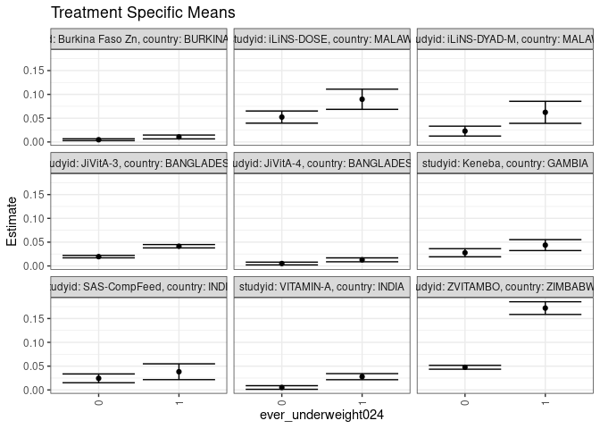

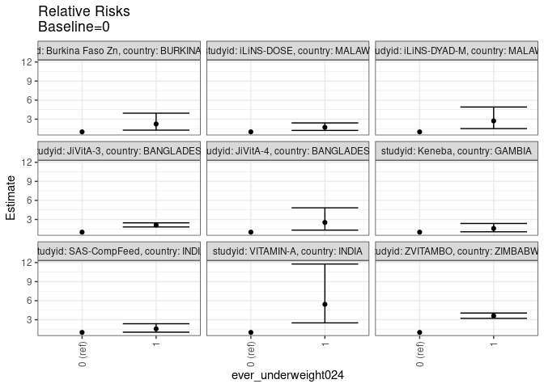

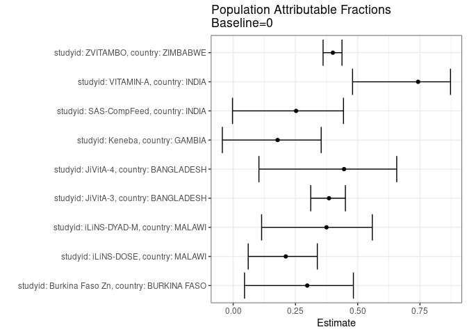

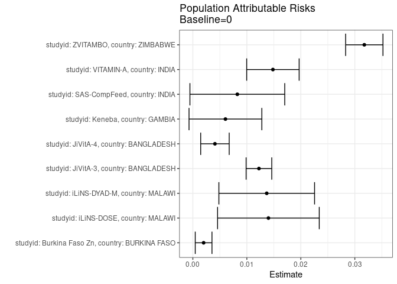

## Results Table

### Parameter: TSM

| studyid | country | intervention_level | baseline_level | estimate | ci_lower | ci_upper |
| --- | --- | --- | --- | --- | --- | --- |
| Burkina Faso Zn | BURKINA FASO | 0 | NA | 0.0047074 | 0.0027465 | 0.0066682 |
| Burkina Faso Zn | BURKINA FASO | 1 | NA | 0.0105292 | 0.0064750 | 0.0145834 |
| iLiNS-DOSE | MALAWI | 0 | NA | 0.0522898 | 0.0395368 | 0.0650428 |
| iLiNS-DOSE | MALAWI | 1 | NA | 0.0897463 | 0.0685398 | 0.1109528 |
| iLiNS-DYAD-M | MALAWI | 0 | NA | 0.0228330 | 0.0124421 | 0.0332239 |
| iLiNS-DYAD-M | MALAWI | 1 | NA | 0.0622998 | 0.0391252 | 0.0854743 |
| JiVitA-3 | BANGLADESH | 0 | NA | 0.0195650 | 0.0169910 | 0.0221390 |
| JiVitA-3 | BANGLADESH | 1 | NA | 0.0413976 | 0.0378919 | 0.0449032 |
| JiVitA-4 | BANGLADESH | 0 | NA | 0.0050962 | 0.0021847 | 0.0080078 |
| JiVitA-4 | BANGLADESH | 1 | NA | 0.0128635 | 0.0087658 | 0.0169612 |
| Keneba | GAMBIA | 0 | NA | 0.0277671 | 0.0192087 | 0.0363256 |
| Keneba | GAMBIA | 1 | NA | 0.0437817 | 0.0322801 | 0.0552834 |
| SAS-CompFeed | INDIA | 0 | NA | 0.0243769 | 0.0151605 | 0.0335932 |
| SAS-CompFeed | INDIA | 1 | NA | 0.0382364 | 0.0216124 | 0.0548604 |
| VITAMIN-A | INDIA | 0 | NA | 0.0051395 | 0.0013415 | 0.0089375 |
| VITAMIN-A | INDIA | 1 | NA | 0.0279088 | 0.0215075 | 0.0343101 |
| ZVITAMBO | ZIMBABWE | 0 | NA | 0.0476106 | 0.0435266 | 0.0516947 |
| ZVITAMBO | ZIMBABWE | 1 | NA | 0.1719215 | 0.1586006 | 0.1852425 |

### Parameter: E(Y)

| studyid | country | intervention_level | baseline_level | estimate | ci_lower | ci_upper |
| --- | --- | --- | --- | --- | --- | --- |
| Burkina Faso Zn | BURKINA FASO | NA | NA | 0.0066992 | 0.0048103 | 0.0085882 |
| iLiNS-DOSE | MALAWI | NA | NA | 0.0662869 | 0.0551877 | 0.0773861 |
| iLiNS-DYAD-M | MALAWI | NA | NA | 0.0365145 | 0.0259198 | 0.0471093 |
| JiVitA-3 | BANGLADESH | NA | NA | 0.0318048 | 0.0296069 | 0.0340028 |
| JiVitA-4 | BANGLADESH | NA | NA | 0.0091861 | 0.0065991 | 0.0117731 |
| Keneba | GAMBIA | NA | NA | 0.0337999 | 0.0272543 | 0.0403456 |
| SAS-CompFeed | INDIA | NA | NA | 0.0326158 | 0.0204960 | 0.0447355 |
| VITAMIN-A | INDIA | NA | NA | 0.0199693 | 0.0155816 | 0.0243570 |
| ZVITAMBO | ZIMBABWE | NA | NA | 0.0793696 | 0.0749054 | 0.0838337 |

### Parameter: RR

| studyid | country | intervention_level | baseline_level | estimate | ci_lower | ci_upper |
| --- | --- | --- | --- | --- | --- | --- |
| Burkina Faso Zn | BURKINA FASO | 0 | 0 | 1.000000 | 1.000000 | 1.000000 |
| Burkina Faso Zn | BURKINA FASO | 1 | 0 | 2.236751 | 1.268420 | 3.944318 |
| iLiNS-DOSE | MALAWI | 0 | 0 | 1.000000 | 1.000000 | 1.000000 |
| iLiNS-DOSE | MALAWI | 1 | 0 | 1.716326 | 1.222401 | 2.409827 |
| iLiNS-DYAD-M | MALAWI | 0 | 0 | 1.000000 | 1.000000 | 1.000000 |
| iLiNS-DYAD-M | MALAWI | 1 | 0 | 2.728498 | 1.515530 | 4.912276 |
| JiVitA-3 | BANGLADESH | 0 | 0 | 1.000000 | 1.000000 | 1.000000 |
| JiVitA-3 | BANGLADESH | 1 | 0 | 2.115895 | 1.815169 | 2.466443 |
| JiVitA-4 | BANGLADESH | 0 | 0 | 1.000000 | 1.000000 | 1.000000 |
| JiVitA-4 | BANGLADESH | 1 | 0 | 2.524121 | 1.318496 | 4.832164 |
| Keneba | GAMBIA | 0 | 0 | 1.000000 | 1.000000 | 1.000000 |
| Keneba | GAMBIA | 1 | 0 | 1.576747 | 1.051456 | 2.364466 |
| SAS-CompFeed | INDIA | 0 | 0 | 1.000000 | 1.000000 | 1.000000 |
| SAS-CompFeed | INDIA | 1 | 0 | 1.568553 | 1.038552 | 2.369028 |
| VITAMIN-A | INDIA | 0 | 0 | 1.000000 | 1.000000 | 1.000000 |
| VITAMIN-A | INDIA | 1 | 0 | 5.430256 | 2.504838 | 11.772289 |
| ZVITAMBO | ZIMBABWE | 0 | 0 | 1.000000 | 1.000000 | 1.000000 |
| ZVITAMBO | ZIMBABWE | 1 | 0 | 3.610990 | 3.218489 | 4.051358 |

### Parameter: PAR

| studyid | country | intervention_level | baseline_level | estimate | ci_lower | ci_upper |
| --- | --- | --- | --- | --- | --- | --- |
| Burkina Faso Zn | BURKINA FASO | 0 | NA | 0.0019919 | 0.0004447 | 0.0035391 |
| iLiNS-DOSE | MALAWI | 0 | NA | 0.0139971 | 0.0045796 | 0.0234146 |
| iLiNS-DYAD-M | MALAWI | 0 | NA | 0.0136815 | 0.0048201 | 0.0225430 |
| JiVitA-3 | BANGLADESH | 0 | NA | 0.0122398 | 0.0098639 | 0.0146157 |
| JiVitA-4 | BANGLADESH | 0 | NA | 0.0040899 | 0.0014496 | 0.0067302 |
| Keneba | GAMBIA | 0 | NA | 0.0060328 | -0.0007112 | 0.0127768 |
| SAS-CompFeed | INDIA | 0 | NA | 0.0082389 | -0.0005415 | 0.0170194 |
| VITAMIN-A | INDIA | 0 | NA | 0.0148298 | 0.0099700 | 0.0196895 |
| ZVITAMBO | ZIMBABWE | 0 | NA | 0.0317590 | 0.0283004 | 0.0352175 |

### Parameter: PAF

| studyid | country | intervention_level | baseline_level | estimate | ci_lower | ci_upper |
| --- | --- | --- | --- | --- | --- | --- |
| Burkina Faso Zn | BURKINA FASO | 0 | NA | 0.2973281 | 0.0454409 | 0.4827478 |
| iLiNS-DOSE | MALAWI | 0 | NA | 0.2111598 | 0.0602488 | 0.3378366 |
| iLiNS-DYAD-M | MALAWI | 0 | NA | 0.3746876 | 0.1141150 | 0.5586159 |
| JiVitA-3 | BANGLADESH | 0 | NA | 0.3848409 | 0.3113214 | 0.4505119 |
| JiVitA-4 | BANGLADESH | 0 | NA | 0.4452254 | 0.1032760 | 0.6567786 |
| Keneba | GAMBIA | 0 | NA | 0.1784856 | -0.0436267 | 0.3533263 |
| SAS-CompFeed | INDIA | 0 | NA | 0.2526053 | -0.0027937 | 0.4429574 |
| VITAMIN-A | INDIA | 0 | NA | 0.7426296 | 0.4793676 | 0.8727711 |
| ZVITAMBO | ZIMBABWE | 0 | NA | 0.4001401 | 0.3609784 | 0.4369019 |